# From myth to reality: Globalisation and public spending in OECD countries revisited

Busemeyer, Marius R. (2009)

# 1 Challenging conventional wisdom

- This article questions the mainstream view in globalization literature.
- That dominant view is coherent but biased and premature.
- It is too early to conclude that globalization has no negative impact on national public spending in OECD countries.
- In fact, the association between increasing openness and public spending is negative over time.

# 2 What if we wait a little longer?

- The conventional wisdom may reflect a temporary phase of globalization.
- Results may change as globalization deepens.
- It’s crucial to examine longer periods to assess its real impact (until 2004)

# 3 Competing Theories

# 4 Data and methodology

- Traditional approaches: Uses total public spending and public social expenditure as % of GDP.
- Busemeyer’s contribution: adds a residual category as **non-social spending** -
- IV:Economic openness (measured via trade openness)
- Control variables:
  - Unemployment
  - Inflation
  - Time trends
  - Economic well-being
  - Female labor force participation
  - Maastricht effect (EU-related fiscal limitations)

# 5 Results

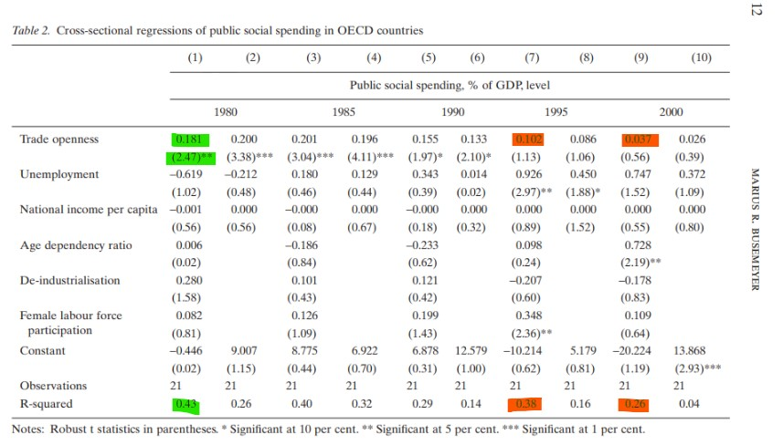

## 5.1 Interpretations

- In 1980, each 1 percentage point increase in trade openness was associated with a 0.18-point increase in public spending (full model).
- From the 1990s onward, this effect shrinks progressively.
- By 2000, there is no statistically significant association between openness and public spending.
- The model’s R² drops from 0.43 (1980) to 0.26 (2000).
- Over time, the model loses much of its explanatory power.

# 6 Conclusions

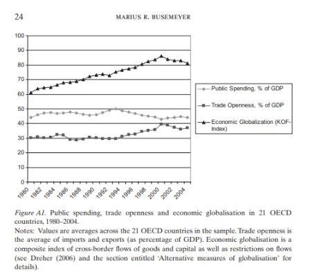

- The positive effects of globalization on public and social spending have weakened over time.
- In the 1980s and early 1990s, globalization may have contributed to welfare expansion.
- But from the 2000s, the negative scenario becomes more prominent.
- It’s essential to study globalization across longer time periods, including the 2000s.
- Pay attention to both cross-sectional and over-time dimensions.

# 7 Question

- Given that the positive relationship between globalization and social spending seems to weaken over time, can we still argue that economic openness strengthens the welfare state? Or is this a temporary compensation effect that fades as globalization deepens?

Catalina Zaza